# Séries temporais

Author

Pedro Monteiro de Almeida Junior

# Conteúdo programático

1. **Conceitos inicias em séries temporais**
   - Objetivos de séries temporais
   - Análise descritiva com séries temporais
   - Tendência
   - Sazonalidade
   - Estacionariedade
   - exemplos práticos de aplicações em séries temporais
2. **Modelos de Suavização exponencial**
   - Médias móveis simples
   - Suavização exponencial simples
   - Suavização exponencial de Holt
   - Suavização exponencial sazonal de Holt-Winters
3. **Modelos AR, MA, ARMA e ARIMA**
   - Modelos Autoregressivos (AR)
   - Modelos de médias móveis (MA)
   - Modelos Autoregressivos e de médias móveis (ARMA)
   - Modelos Autoregressivos e de médias móveis integrados(ARIMA)
   - Identificação das ordens dos modelos
   - critério para seleção dos modelos
   - Previsão e medidas de avaliação
   - diagnóstico dos modelos
   - Exemplos práticos no R
4. **Projetos Práticos**
   - Modelos de séries temporais não gaussianas (GARMA)
   - Modelos ARCH e GARCH
   - Modelos de séries temporais não paramétricos
   - Modelo ETS
   - Exemplos práticos no R
   - Introdução ao Python e aplicações

# Referências bibliográficas

[1] SHUMWAY R. H. STOFFER, D. S. Time series analysis and its applications with R examples. 3°ed. New York: Springer, 2010.

[2] MORETTIN, P.A. Análise de Séries Temporais. S. Paulo, Edgard Blucher, 2006.

[3] BROCKWELL, P. & DAVIS, R. Introduction to Time Series and Forecasting. Springer, 1996.

[4] HAMILTON, J.D. Time Series Analysis.

[5] Forecasting: Principles and Practice (3rd ed). *Rob J Hyndman and George Athanasopoulos.* Monash University, Australia. [Versão online](https://otexts.com/fpp3/)

## Sites com exemplos em séries temporais

https://www.kaggle.com/

https://data.world/datasets/time-series

https://medium.com/analytics-vidhya/10-time-series-datasets-for-practice-d14fec9f21bc

https://dados.gov.br/dataset

http://ipeadata.gov.br/Default.aspx

https://campinagrande.pb.gov.br/portal-da-transparencia/

http://dados.recife.pe.gov.br/

https://transparencia.joaopessoa.pb.gov.br/#/

# Conceitos iniciais em séries temporais

Uma série temporal é qualquer conjunto de observações ordenadas ao longo do tempo. A seguir, temos alguns exemplos de séries temporais:

- valores diários de precipitação de chuva em campina grande;
- quantidade de assaltos semanais em uma determinada região;
- índices diários da Bolsa de Valores de São Paulo;
- valor gasto com gasolina anualmente por orgãos públicos;
- registros do fluxo de carros em um estacionamento por hora;

Estes são alguns, dos mais diversos exemplos nos quais podemos aplicar as técnicas de séries temporais. Note que, essa técnica pode ser aplicada para diferentes medidas de tempo: Segundos, minutos, hora, dia, semana, mês e ano.

#### Objetivos principais

As análises usando séries temporais têm como principais objetivos:

(i) Fazer previsões de valores futuros da série;

(ii) Descrever o comportamento da série;

(iii) Identificar periodicidades relevantes nos dados;

#### Domínio temporal e espectral

Existem, basicamente, dois enfoques usados na análise de séries temporais. No primeiro, a análise é feita sobre o domínio temporal (será o enfoque do curso) e no domínio de frequência, que temos a análise espectral com aplicações principalmente na área da engenharia e física.

#### Notação

Seja $Z_t$ uma variável aleatória no instante $t$ ( Por exemplo, a temperatura no tempo $t$ ). De modo geral, uma série temporal poderá ser representado por um vetor ${Z}_{t_1}, \ldots, Z_{t_n}$.

#### Tendência

Uma das principais características para se observar em uma série temporal é a tendência. Ou seja, identificar se a série apresenta um comportamento crescente ou decrescente ao longo do tempo. Por exemplo, no gráfico abaixo podemos identificar que em determinado tempo a série apresentou um comportamento de tendência crescente até obter uma certa estabilidade novamente.

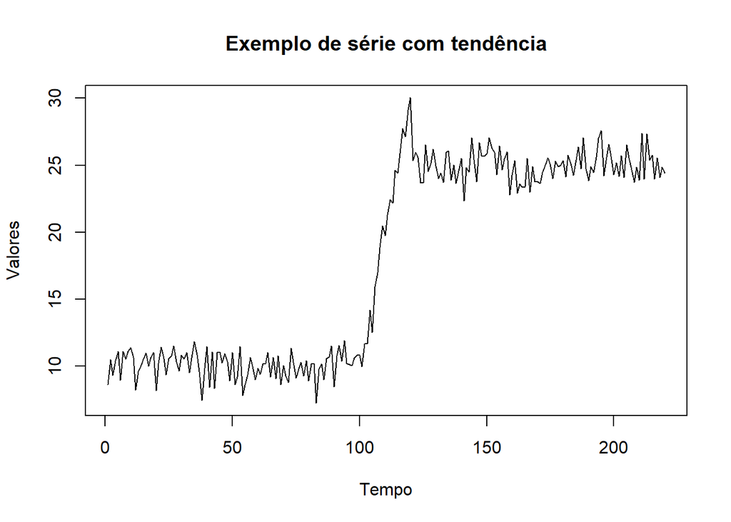

#### Sazonalidade

O componente de sazonalidade também é outra característica importante para observar-se em uma série temporal. Esse componente determina se existe um comportamento sazonal ou cíclico, ou seja, se uma série observada apresenta um comportamento que se repete de tempos em tempos. A seguir, é fornecido um exemplo de uma série temporal que apresenta esse tipo de comportamento.

```r
## Carregando os pacotes
library(TSA)
library(forecast)
```

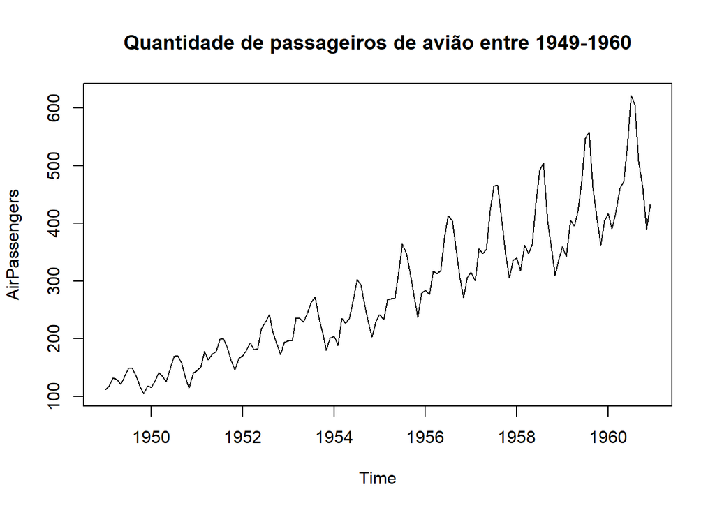

```r
data("AirPassengers")
plot.ts(AirPassengers, main = 'Quantidade de passageiros de avião entre 1949-1960')
```

#### Estacionariedade

Uma das suposições que podemos fazer em uma série temporal é a de que ela é **estacionária**. Isto é, ao longo do tempo seus valores estão aleatoriamente próximos de uma média constante, refletindo de alguma forma um equilíbrio estável. No gráfico a seguir, tempos um exemplo de uma série temporal estacionária.

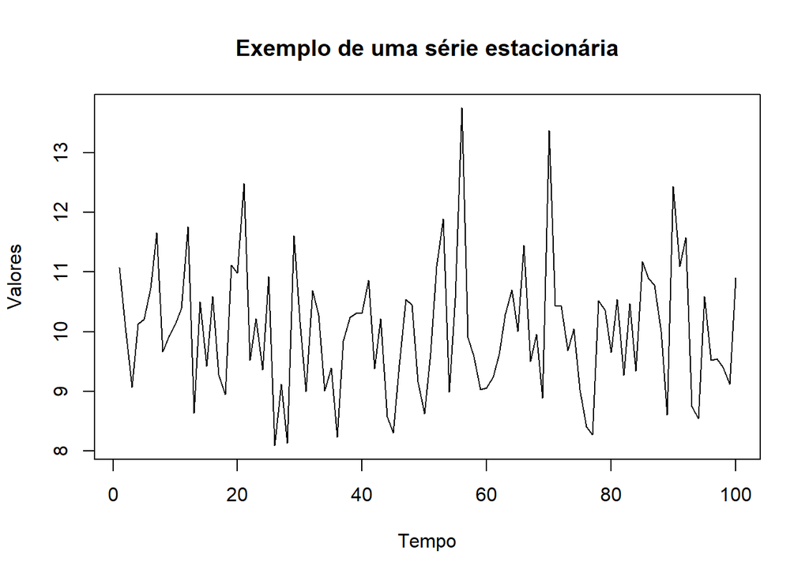

Contudo, em várias situações práticas, vamos ter que lidar com **séries não estacionárias**. É bastante comum, por exemplo, em séries econômicas e financeiras a presença de tendências de longos períodos ou curtos períodos (o que geralmente caracteriza uma mudança de nível). Dessa forma, em alguns modelos estatísticos de séries temporais, vamos ter que “tratar” a não estacionariedade das séres através de transformações. A transformação mais comum seria tomar diferenças sucessivas da série original, até obter uma série estacionária.

##### Operador Diferença

o operador diferença ( $\Delta$ ) de primeira ordem pode ser definido como

$$\Delta Z_t = Z_t - Z_{t-1}$$

a segunda diferença é

$$\Delta^2Z_t = \Delta[ \Delta Z_t ] = \Delta [ Z_t - Z_{t-1} ]$$

De modo geral, a n-ésima diferença de $Z_t$ é

$$\Delta^n Z_t = \Delta[ \Delta^{n-1} Z_t ]$$

Na prática, é comum tomar uma ou duas diferenças para tornar a série temporal estacionária. O exemplo a seguir, ilustra como o operador diferença pode tornar uma série claramente não estacionária em uma série estacionária.

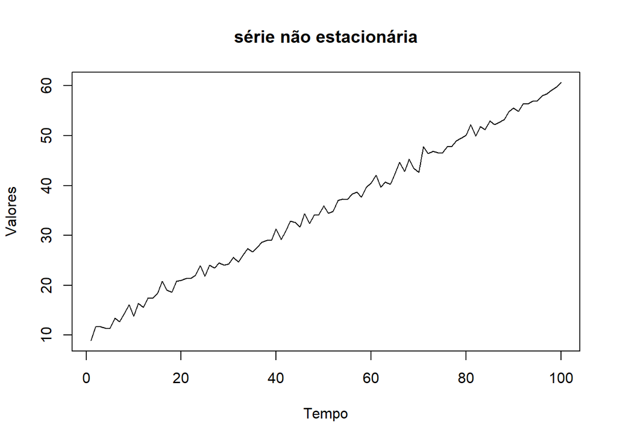

```r
### Exemplo simulado no R:
x1 = c()
for (i in 1:100) x1[i] = rnorm(1, mean = 10+(i/2), sd = 1)
x2 = diff(x1, 1)

plot.ts(x1, xlab = "Tempo", ylab = "Valores", main = "série não estacionária" )
```

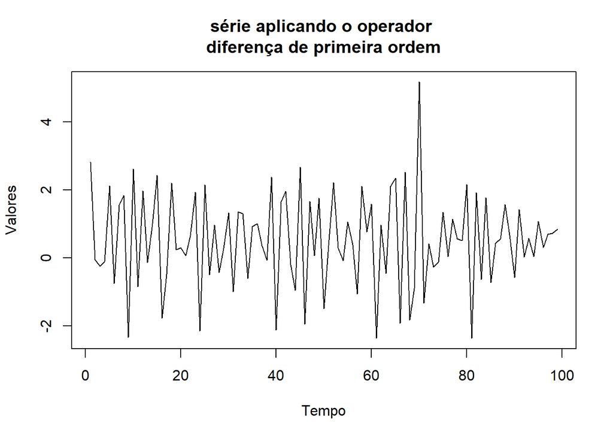

```r
plot.ts(x2, xlab = "Tempo", ylab = "Valores", main = "série aplicando o operador \ndiferença de primeira ordem" )
```